# Introduction aux méthodes de spatialisation des données avec R

Introduction à R

Prof. Silvio J. Gumiere, P.Eng, Ph.D.

2025-06-17

# Introduction à R

## Qu’est-ce que R ?

R est un langage de programmation et un environnement logiciel libre spécialement conçu pour l’analyse statistique et la visualisation de données. Pour les agronomes, R offre des outils puissants pour :

- Analyser les données d’expérimentations agricoles
- Modéliser les rendements et les facteurs de production
- Cartographier et analyser la variabilité spatiale des cultures
- Effectuer des analyses statistiques avancées
- Créer des visualisations de qualité publication

## Utilisation de Posit Cloud (recommandé)

Pour ce cours, nous utiliserons **Posit Cloud** (anciennement RStudio Cloud), une plateforme en ligne qui permet d’utiliser R et RStudio directement dans votre navigateur web, sans installation locale.

### Avantages de Posit Cloud :

- Aucune installation requise
- Environnement standardisé pour tous les participants
- Accès depuis n’importe quel ordinateur avec internet
- Packages pré-installés
- Sauvegarde automatique dans le cloud

### Accès à Posit Cloud :

1. Rendez-vous sur posit.cloud
2. Créez un compte gratuit
3. Cliquez sur “New Project” > “New RStudio Project”
4. Votre environnement R est prêt !

```r
# Vérifier que tout fonctionne
R.version.string
Sys.Date()
```

## Installation locale (optionnel)

Si vous souhaitez installer R localement :

```r
# Installation de R depuis https://cran.r-project.org/
# Installation de RStudio depuis https://posit.co/downloads/

# Vérifier la version de R
R.version.string
```

## Les packages essentiels pour l’agronomie

```r
# Installation des packages principaux
install.packages(c("tidyverse", "sf", "raster", "sp", "gstat",
                   "ggplot2", "dplyr", "rgdal"))

# Chargement des librairies
library(tidyverse)
library(sf)
library(raster)
library(gstat)
```

# Types de données en agronomie

## 1. Données numériques

### Variables continues

```r
# Exemple : rendements en tonnes par hectare
rendements <- c(12.5, 15.2, 13.8, 16.1, 14.3, 11.9, 17.2, 13.5)
print(rendements)
```

```
## [1] 12.5 15.2 13.8 16.1 14.3 11.9 17.2 13.5
```

```r
# Statistiques descriptives
summary(rendements)
```

```
##    Min. 1st Qu.  Median    Mean 3rd Qu.    Max.
##   11.90   13.25   14.05   14.31   15.43   17.20
```

```r
mean(rendements)
```

```
## [1] 14.3125
```

```r
sd(rendements)
```

```
## [1] 1.786807
```

### Variables discrètes

```r
# Exemple : nombre de plants par parcelle
nb_plants <- c(45, 52, 48, 50, 46, 53, 49, 51)
print(nb_plants)
```

```
## [1] 45 52 48 50 46 53 49 51
```

## 2. Données catégorielles

### Variables nominales

```r
# Exemple : types de sol
types_sol <- factor(c("Argilo-limoneux", "Sableux", "Argileux",
                      "Limoneux", "Argilo-limoneux", "Sableux"))
print(types_sol)
```

```
## [1] Argilo-limoneux Sableux         Argileux        Limoneux
## [5] Argilo-limoneux Sableux
## Levels: Argileux Argilo-limoneux Limoneux Sableux
```

```r
table(types_sol)
```

```
## types_sol
##        Argileux Argilo-limoneux        Limoneux         Sableux
##               1               2               1               2
```

### Variables ordinales

```r
# Exemple : stades phénologiques
stades <- factor(c("Levée", "Tallage", "Montaison", "Épiaison", "Maturation"),
                 levels = c("Levée", "Tallage", "Montaison", "Épiaison", "Maturation"),
                 ordered = TRUE)
print(stades)
```

```
## [1] Levée      Tallage    Montaison  Épiaison   Maturation
## Levels: Levée < Tallage < Montaison < Épiaison < Maturation
```

## 3. Données temporelles

```r
# Dates de semis
dates_semis <- as.Date(c("2024-03-15", "2024-03-20", "2024-03-25", "2024-04-01"))
print(dates_semis)
```

```
## [1] "2024-03-15" "2024-03-20" "2024-03-25" "2024-04-01"
```

```r
# Calcul de durées
duree_croissance <- as.numeric(Sys.Date() - dates_semis)
print(duree_croissance)
```

```
## [1] 459 454 449 442
```

## 4. Données spatiales

Les données spatiales sont cruciales en agronomie pour comprendre la variabilité des champs.

```r
# Création d'un exemple de données spatiales
coordonnees <- data.frame(
  x = c(100, 150, 200, 250, 300),
  y = c(50, 100, 150, 200, 250),
  rendement = c(12.5, 15.2, 13.8, 16.1, 14.3),
  pH = c(6.2, 6.8, 6.5, 7.1, 6.9)
)

print(coordonnees)
```

```
##     x   y rendement  pH
## 1 100  50      12.5 6.2
## 2 150 100      15.2 6.8
## 3 200 150      13.8 6.5
## 4 250 200      16.1 7.1
## 5 300 250      14.3 6.9
```

# Introduction à la variabilité spatiale

## Concept de variabilité spatiale

La variabilité spatiale en agronomie fait référence aux variations des propriétés du sol, des rendements, ou d’autres variables agricoles à travers l’espace géographique. Cette variabilité peut être due à :

- **Facteurs pédologiques** : texture, structure, pH, matière organique
- **Facteurs topographiques** : pente, exposition, drainage
- **Facteurs climatiques** : précipitations, température, évapotranspiration
- **Pratiques agricoles** : fertilisation, irrigation, travail du sol

## Pourquoi analyser la variabilité spatiale ?

1. **Agriculture de précision** : adapter les pratiques aux conditions locales
2. **Optimisation des intrants** : réduire les coûts et l’impact environnemental
3. **Amélioration des rendements** : identifier les zones à potentiel
4. **Gestion durable** : préserver la qualité des sols

## Exemple simple de visualisation spatiale

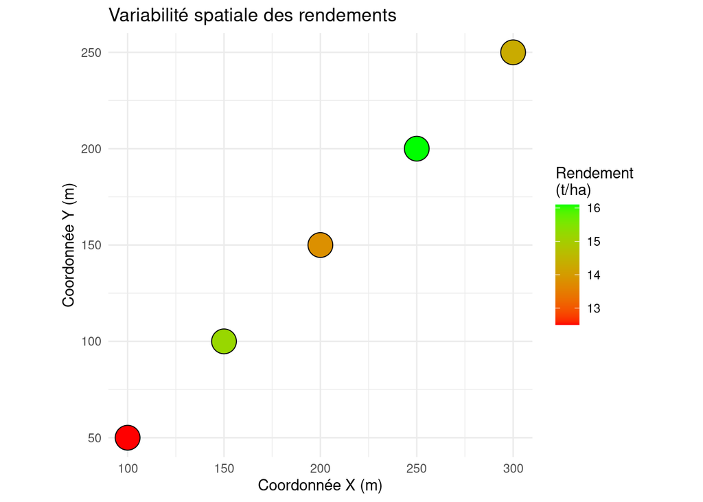

```r
library(ggplot2)

# Création d'une carte simple des rendements
ggplot(coordonnees, aes(x = x, y = y, fill = rendement)) +
  geom_point(size = 8, shape = 21, color = "black") +
  scale_fill_gradient(low = "red", high = "green", name = "Rendement\n(t/ha)") +
  labs(title = "Variabilité spatiale des rendements",
       x = "Coordonnée X (m)",
       y = "Coordonnée Y (m)") +
  theme_minimal() +
  coord_equal()
```

## Structure des données spatiales

```r
# Exemple de structure de données pour l'analyse spatiale
donnees_parcelle <- data.frame(
  parcelle_id = 1:20,
  x_coord = runif(20, 0, 1000),
  y_coord = runif(20, 0, 800),
  rendement = rnorm(20, 14, 2),
  pH = rnorm(20, 6.5, 0.5),
  matiere_organique = rnorm(20, 2.5, 0.3),
  azote = rnorm(20, 45, 8),
  phosphore = rnorm(20, 25, 5)
)

# Aperçu des données
head(donnees_parcelle)
```

```
##   parcelle_id   x_coord  y_coord rendement       pH matiere_organique    azote
## 1           1 198.76091 623.1783  15.92517 6.865783          2.277230 57.36474
## 2           2  41.79971 483.0426  16.10846 7.237941          2.401842 39.73669
## 3           3 461.14278 453.9854  15.96018 7.041362          2.408339 44.66081
## 4           4 328.37358 464.3428  16.68330 7.643451          2.707877 44.46949
## 5           5 422.96718 304.1233  13.42998 6.939187          2.606516 37.72399
## 6           6 392.88318 614.1200  14.61532 7.112501          2.227323 37.47131
##   phosphore
## 1  19.77654
## 2  23.67386
## 3  27.42541
## 4  24.48053
## 5  21.19987
## 6  28.63692
```

## Corrélations spatiales

```r
# Matrice de corrélation
cor_matrix <- cor(donnees_parcelle[, c("rendement", "pH", "matiere_organique", "azote", "phosphore")])
print(round(cor_matrix, 2))
```

```
##                   rendement    pH matiere_organique azote phosphore
## rendement              1.00  0.63             -0.13  0.22     -0.15
## pH                     0.63  1.00             -0.07 -0.03     -0.23
## matiere_organique     -0.13 -0.07              1.00 -0.16      0.24
## azote                  0.22 -0.03             -0.16  1.00     -0.07
## phosphore             -0.15 -0.23              0.24 -0.07      1.00
```

# Lecture des donnes spatiales

lien pour les données : [Lien pour les données](https://github.com/sgumiere/CMTSAES)

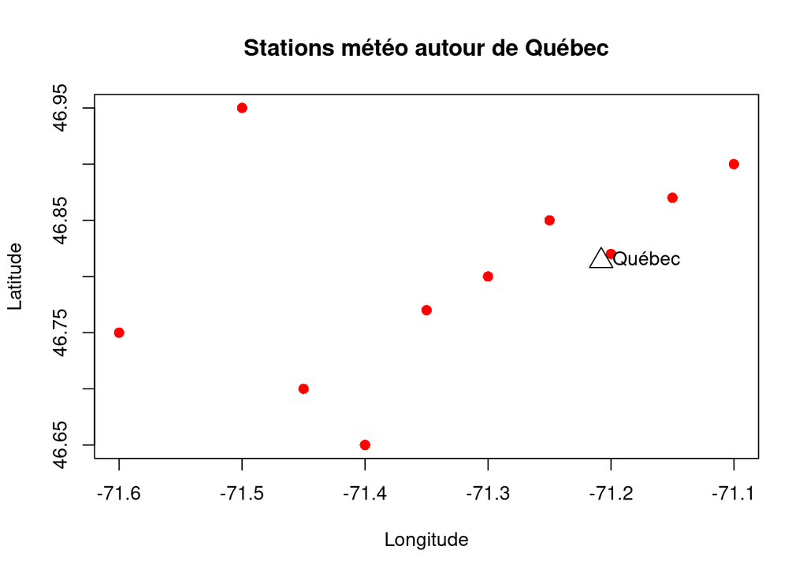

```r
# Chargement des packages nécessaires
library(leaflet)
library(sp)
library(sf)

# Données des stations météo
stations = read.csv('stations_meteos_quebec')

# Coordonnées de Québec
quebec <- data.frame(longitude = -71.2080, latitude = 46.8139)

# Graphique simple
plot(stations$longitude, stations$latitude,
     main = "Stations météo autour de Québec",
     xlab = "Longitude", ylab = "Latitude",
     pch = 16, col = "red", cex = 1.2)
points(quebec$longitude, quebec$latitude, pch = 2, cex = 2)
text(quebec$longitude, quebec$latitude, 'Québec', pos = 4)
```

## On peut faire mieux!!!

```r
# Génération de données de précipitations
set.seed(123)
stations$precip <- round(runif(nrow(stations), 0, 50), 1)

# Carte interactive avec les données de précipitations
leaflet(stations) %>%
  addTiles() %>%
  addCircleMarkers(
    lng = ~longitude,
    lat = ~latitude,
    radius = ~sqrt(precip) * 2,  # Taille proportionnelle aux précipitations
    color = "blue",
    fillColor = "red",
    fillOpacity = 0.7,
    popup = ~paste0("Station ", nom, "<br>Précipitations: ", precip, " mm")
  ) %>%
  addMarkers(
    lng = quebec$longitude,
    lat = quebec$latitude,
    popup = "Ville de Québec"
  )
```

[interactive chart not shown]

### Lecture de données vectorielles avec sf

Le package `sf` (simple features) est l’outil moderne pour travailler avec des données vectorielles. Très utile pour les parcelles agricoles !

```r
library(sf)


# Lire le shapefile
donnees_sol <- st_read("pedo_21m09101/Pedo_21M09101.shp")
```

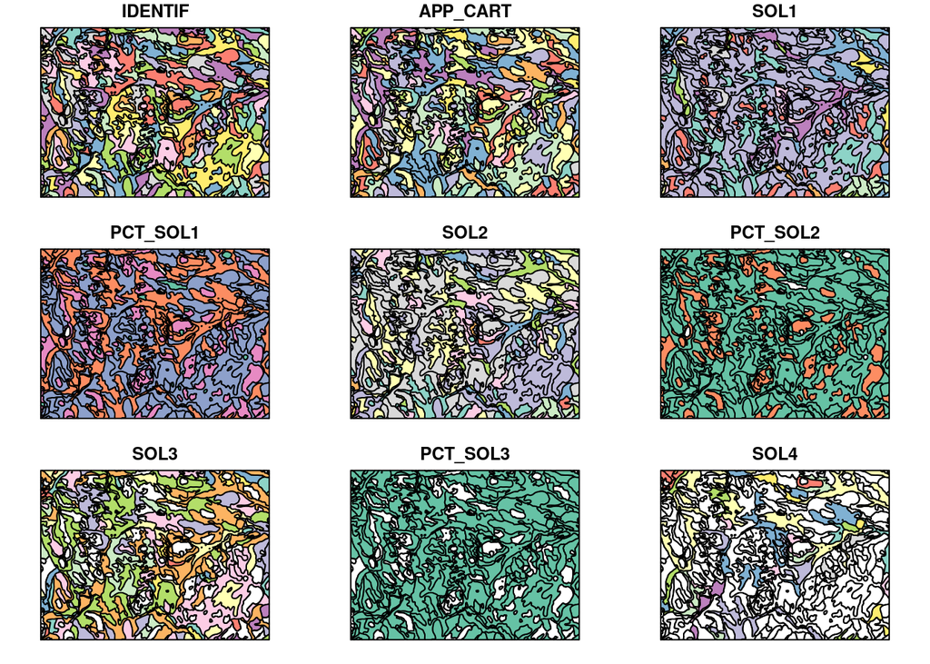

```r
plot(donnees_sol)
```

On peut afficher un attribut:

```r
# Lire le shapefile
donnees_sol <- st_read("pedo_21m09101/Pedo_21M09101.shp")
```

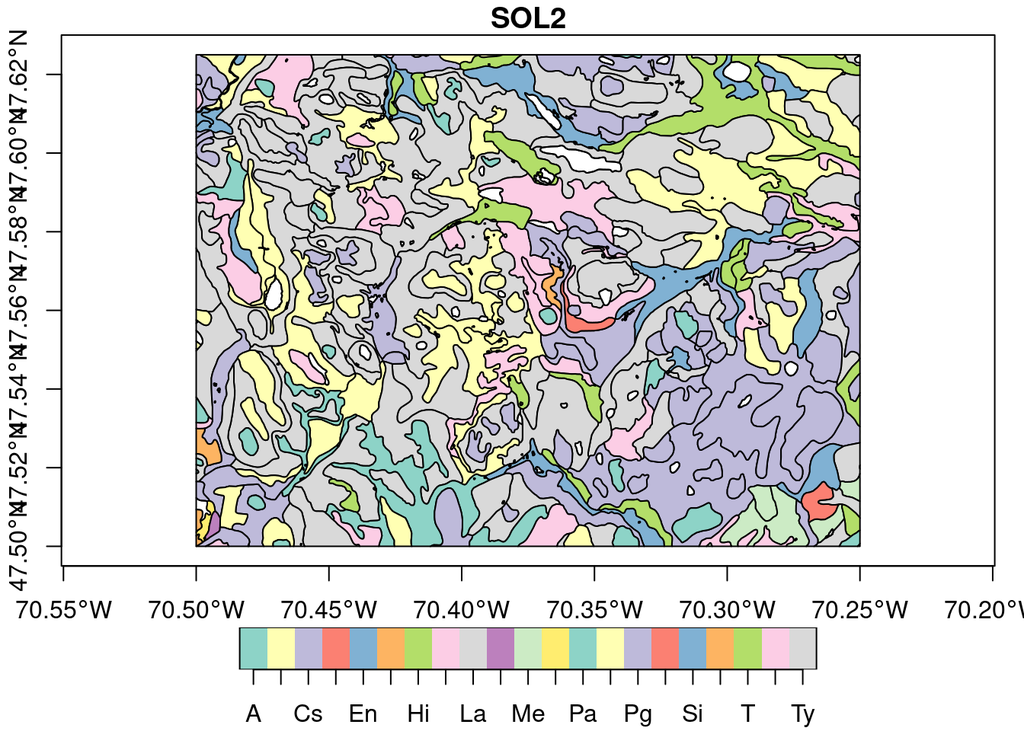

```r
plot(donnees_sol['SOL2'], key.pos = 1, axes = TRUE)
```

# Lecture des Rasters

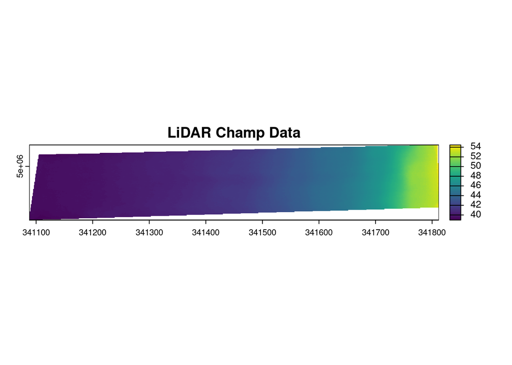

```r
# Load required libraries
library(terra)    # Modern raster package (recommended)
# Alternative: library(raster)  # Older but still widely used

raster_data <- rast('lidar_Touga.tif')

# Basic plot
plot(raster_data, main = "LiDAR Champ Data")
```

# Exercices pratiques

## Exercice 1 : Création d’un jeu de données

Créez un data.frame avec les variables suivantes pour 50 parcelles : - ID de la parcelle - Coordonnées X et Y - Rendement en blé (moyenne 12 t/ha, écart-type 2) - Teneur en azote du sol (moyenne 40 mg/kg, écart-type 10)

```r
# Votre code ici
```

## Exercice 2 : Analyse descriptive

Calculez les statistiques descriptives pour le rendement et créez un histogramme.

```r
# Votre code ici
```

## Exercice 3 : Visualisation spatiale

Créez une carte montrant la répartition spatiale des rendements avec une légende colorée.

```r
# Votre code ici
```

# Solutions des exercices

**Cliquez pour voir les solutions**

## Solution Exercice 1 : Création d’un jeu de données

```r
# Créer un data.frame avec 50 parcelles
set.seed(123)  # Pour reproduire les mêmes résultats

exercice1_donnees <- data.frame(
  parcelle_id = 1:50,
  x_coord = runif(50, 0, 1000),  # Coordonnées X entre 0 et 1000m
  y_coord = runif(50, 0, 800),   # Coordonnées Y entre 0 et 800m
  rendement_ble = rnorm(50, mean = 12, sd = 2),  # Rendement normal, moyenne 12 t/ha
  azote_sol = rnorm(50, mean = 40, sd = 10)      # Azote normal, moyenne 40 mg/kg
)

# Afficher les premières lignes
head(exercice1_donnees)
```

```
##   parcelle_id  x_coord   y_coord rendement_ble azote_sol
## 1           1 287.5775  36.66493      12.50664  32.89593
## 2           2 788.3051 353.76006      11.94291  42.56884
## 3           3 408.9769 639.13988      11.91426  37.53308
## 4           4 883.0174  97.51941      14.73720  36.52457
## 5           5 940.4673 448.75839      11.54846  30.48381
## 6           6  45.5565 165.22511      15.03294  39.54972
```

```r
# Afficher la structure des données
str(exercice1_donnees)
```

```
## 'data.frame':    50 obs. of  5 variables:
##  $ parcelle_id  : int  1 2 3 4 5 6 7 8 9 10 ...
##  $ x_coord      : num  288 788 409 883 940 ...
##  $ y_coord      : num  36.7 353.8 639.1 97.5 448.8 ...
##  $ rendement_ble: num  12.5 11.9 11.9 14.7 11.5 ...
##  $ azote_sol    : num  32.9 42.6 37.5 36.5 30.5 ...
```

```r
# Résumé statistique
summary(exercice1_donnees)
```

```
##   parcelle_id       x_coord          y_coord         rendement_ble
##  Min.   : 1.00   Min.   : 24.61   Min.   :  0.4998   Min.   : 7.382
##  1st Qu.:13.25   1st Qu.:271.37   1st Qu.:180.7952   1st Qu.:11.277
##  Median :25.50   Median :502.95   Median :356.2866   Median :12.305
##  Mean   :25.50   Mean   :520.09   Mean   :381.6216   Mean   :12.293
##  3rd Qu.:37.75   3rd Qu.:780.84   3rd Qu.:594.0212   3rd Qu.:13.259
##  Max.   :50.00   Max.   :994.27   Max.   :787.9656   Max.   :16.375
##    azote_sol
##  Min.   :19.47
##  1st Qu.:30.49
##  Median :36.95
##  Mean   :37.46
##  3rd Qu.:42.90
##  Max.   :61.00
```

## Solution Exercice 2 : Analyse descriptive

```r
# Statistiques descriptives pour le rendement
cat("=== STATISTIQUES DESCRIPTIVES POUR LE RENDEMENT ===\n")
```

```
## === STATISTIQUES DESCRIPTIVES POUR LE RENDEMENT ===
```

```r
cat("Moyenne:", round(mean(exercice1_donnees$rendement_ble), 2), "t/ha\n")
```

```
## Moyenne: 12.29 t/ha
```

```r
cat("Médiane:", round(median(exercice1_donnees$rendement_ble), 2), "t/ha\n")
```

```
## Médiane: 12.31 t/ha
```

```r
cat("Écart-type:", round(sd(exercice1_donnees$rendement_ble), 2), "t/ha\n")
```

```
## Écart-type: 1.81 t/ha
```

```r
cat("Minimum:", round(min(exercice1_donnees$rendement_ble), 2), "t/ha\n")
```

```
## Minimum: 7.38 t/ha
```

```r
cat("Maximum:", round(max(exercice1_donnees$rendement_ble), 2), "t/ha\n")
```

```
## Maximum: 16.37 t/ha
```

```r
# Quartiles
print(quantile(exercice1_donnees$rendement_ble))
```

```
##        0%       25%       50%       75%      100%
##  7.381662 11.277406 12.305158 13.258872 16.374666
```

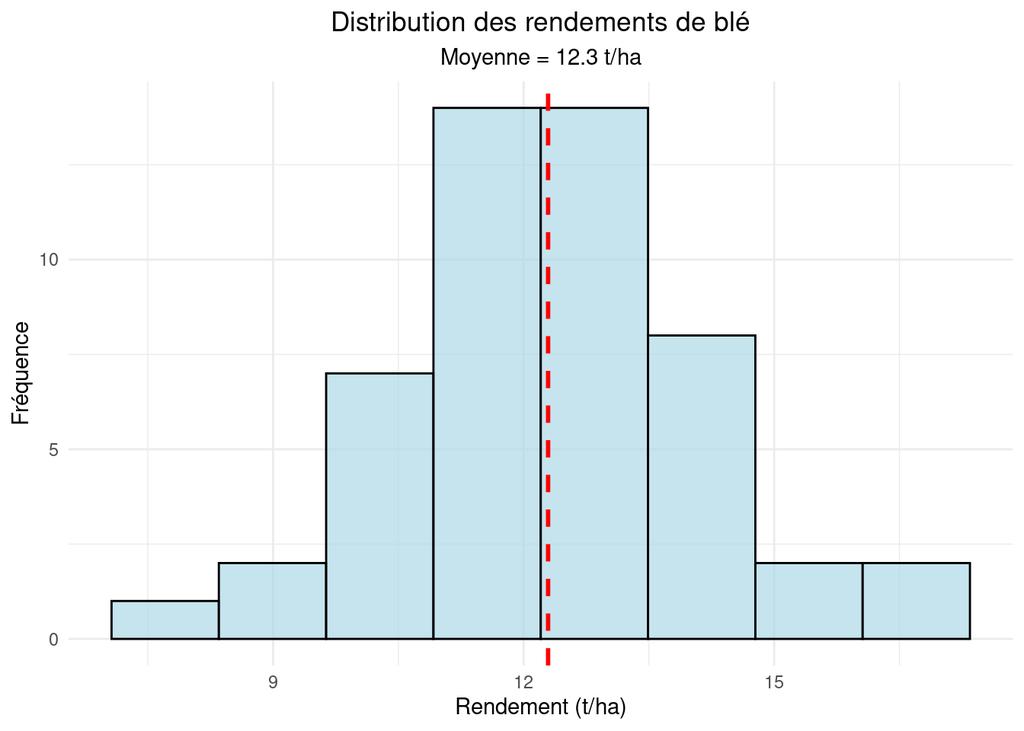

```r
# Histogramme du rendement
library(ggplot2)

ggplot(exercice1_donnees, aes(x = rendement_ble)) +
  geom_histogram(bins = 8, fill = "lightblue", color = "black", alpha = 0.7) +
  geom_vline(aes(xintercept = mean(rendement_ble)),
             color = "red", linetype = "dashed", size = 1) +
  labs(title = "Distribution des rendements de blé",
       subtitle = paste("Moyenne =", round(mean(exercice1_donnees$rendement_ble), 1), "t/ha"),
       x = "Rendement (t/ha)",
       y = "Fréquence") +
  theme_minimal() +
  theme(plot.title = element_text(hjust = 0.5),
        plot.subtitle = element_text(hjust = 0.5))
```

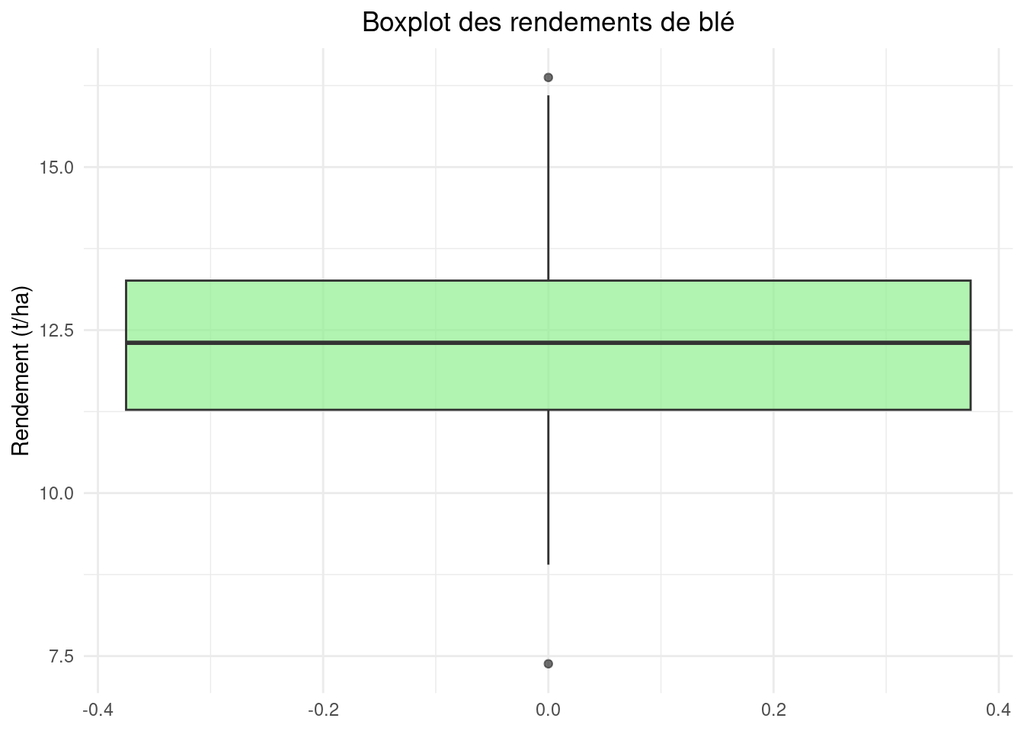

```r
# Boxplot pour détecter les valeurs aberrantes
ggplot(exercice1_donnees, aes(y = rendement_ble)) +
  geom_boxplot(fill = "lightgreen", alpha = 0.7) +
  labs(title = "Boxplot des rendements de blé",
       y = "Rendement (t/ha)") +
  theme_minimal() +
  theme(plot.title = element_text(hjust = 0.5))
```

## Solution Exercice 3 : Visualisation spatiale

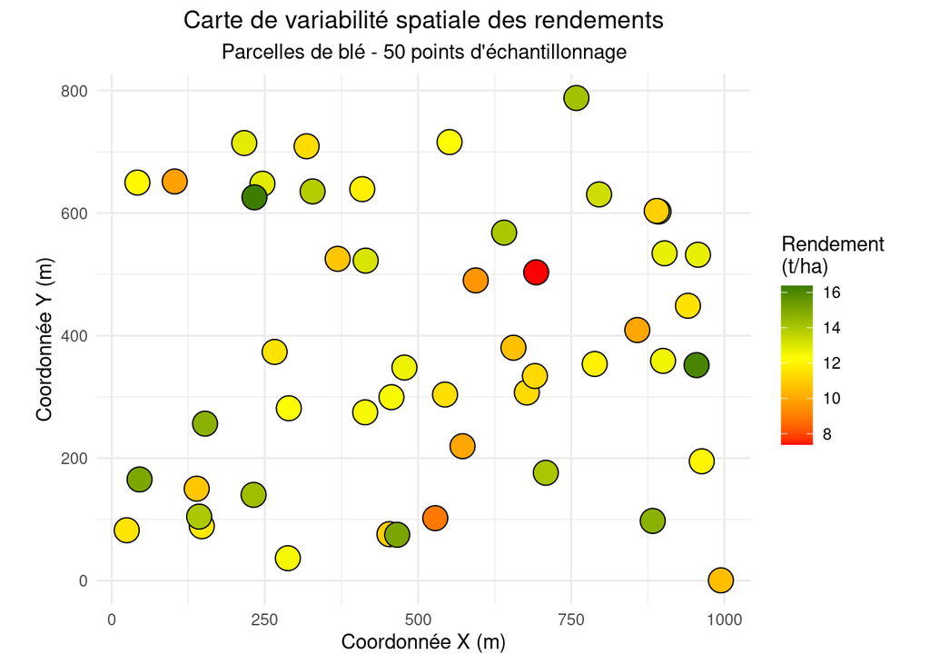

```r
# Carte des rendements avec légende colorée
ggplot(exercice1_donnees, aes(x = x_coord, y = y_coord, fill = rendement_ble)) +
  geom_point(size = 6, shape = 21, color = "black", stroke = 0.5) +
  scale_fill_gradient2(low = "red", mid = "yellow", high = "darkgreen",
                       midpoint = mean(exercice1_donnees$rendement_ble),
                       name = "Rendement\n(t/ha)") +
  labs(title = "Carte de variabilité spatiale des rendements",
       subtitle = "Parcelles de blé - 50 points d'échantillonnage",
       x = "Coordonnée X (m)",
       y = "Coordonnée Y (m)") +
  theme_minimal() +
  theme(plot.title = element_text(hjust = 0.5),
        plot.subtitle = element_text(hjust = 0.5),
        legend.position = "right") +
  coord_equal()
```

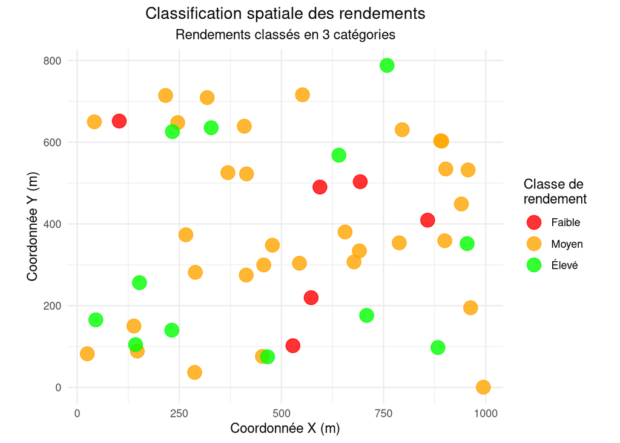

```r
# Carte alternative avec classification en classes
exercice1_donnees$classe_rendement <- cut(exercice1_donnees$rendement_ble,
                                          breaks = 3,
                                          labels = c("Faible", "Moyen", "Élevé"))

ggplot(exercice1_donnees, aes(x = x_coord, y = y_coord, color = classe_rendement)) +
  geom_point(size = 5, alpha = 0.8) +
  scale_color_manual(values = c("red", "orange", "green"),
                     name = "Classe de\nrendement") +
  labs(title = "Classification spatiale des rendements",
       subtitle = "Rendements classés en 3 catégories",
       x = "Coordonnée X (m)",
       y = "Coordonnée Y (m)") +
  theme_minimal() +
  theme(plot.title = element_text(hjust = 0.5),
        plot.subtitle = element_text(hjust = 0.5)) +
  coord_equal()
```

```r
# Corrélation entre variables
cor_rendement_azote <- cor(exercice1_donnees$rendement_ble, exercice1_donnees$azote_sol)
cat("Corrélation rendement-azote:", round(cor_rendement_azote, 3))
```

```
## Corrélation rendement-azote: -0.156
```

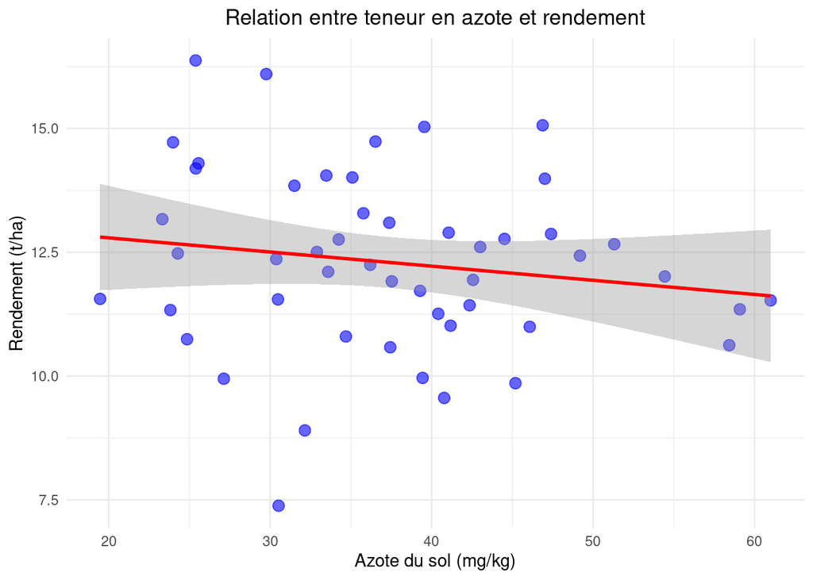

```r
# Graphique de corrélation
ggplot(exercice1_donnees, aes(x = azote_sol, y = rendement_ble)) +
  geom_point(color = "blue", alpha = 0.6, size = 3) +
  geom_smooth(method = "lm", se = TRUE, color = "red") +
  labs(title = "Relation entre teneur en azote et rendement",
       x = "Azote du sol (mg/kg)",
       y = "Rendement (t/ha)") +
  theme_minimal() +
  theme(plot.title = element_text(hjust = 0.5))
```

# Prochaines étapes

Dans les prochains chapitres, nous aborderons :

1. **Analyse exploratoire des données spatiales**
   - Calcul de variogrammes
   - Détection de l’autocorrélation spatiale
2. **Interpolation spatiale**
   - Krigeage ordinaire et universel
   - Validation croisée
3. **Modélisation spatiale**
   - Régression géographiquement pondérée
   - Modèles mixtes spatiaux
4. **Applications en agriculture de précision**
   - Cartes de prescription
   - Zonage de gestion

# Ressources complémentaires

- [Documentation R officielle](https://www.r-project.org/)
- [Cheat sheets RStudio](https://rstudio.com/resources/cheatsheets/)
- Package `sp` pour les données spatiales
- Package `gstat` pour la géostatistique
- Package `agricolae` pour les analyses agricoles

*Ce document constitue une introduction à R pour les agronomes. N’hésitez pas à expérimenter avec le code et à poser des questions !*